# Creating Haul-out Timeline Input Data

document the processing of the ‘raw’ telemetry data into a usable data structure for downstream analysis procedures

Josh M. London https://github.com/jmlondon (NOAA Alaska Fisheries Science Center)  
2021-06-28

## Workflow

This process is managed with a `make_data.R` script. We rely on a series of functions to pull data from the database and, then, tidy and merge into our needed data structure. We will briefly describe each functional step below. Each function can be examined in detail by opening the corresponding R file within the R directory.

### `get_timeline_data()`

The final data structure:

```
Rows: 283,547
Columns: 8
Groups: speno, species, sex, age, unique_day [11,864]
$ speno             <chr> "EB14KKA-136707", "EB14KKA-136707", "EB14K…
$ species           <chr> "bearded", "bearded", "bearded", "bearded"…
$ sex               <chr> "male", "male", "male", "male", "male", "m…
$ age               <chr> "pup", "pup", "pup", "pup", "pup", "pup", …
$ unique_day        <glue> "2015_100", "2015_100", "2015_100", "2015…
$ timeline_start_dt <dttm> 2015-04-10 00:00:00, 2015-04-10 01:00:00,…
$ n_tags            <int> 1, 1, 1, 1, 1, 1, 1, 1, 1, 1, 1, 1, 1, 1, …
$ percent_dry       <dbl> 100, 100, 100, 100, 100, 100, 100, 100, 10…
```

### `get_locs_sf()`

This is also a simple pull and merge of telemetry data from PostgreSQL database. The focus here is on location estimates. As such, we rely on the `sf::read_sf()` function and a custom query:

```sql
SELECT  deployid,
        locs_dt,
        type,
        quality,
        error_radius,
        geom
FROM telem.geo_wc_locs_qa
```

After this query, the process is similar to the `get_timeline_data()` function. We merge with the additional details (e.g. seal species, age, sex) and filter to only include our months of interest (March, April, May, June). Note we also calculate the *unique_day* field that will become the basis for our location averaging.

The final data structure:

```
Rows: 120,942
Columns: 18
$ deployid     <glue> "PL2019_9004_17U2918", "PL2019_9003_17U2925", …
$ ptt          <int> 174823, 174828, 174823, 174815, 174823, 174815,…
$ type         <chr> "Argos", "Argos", "Argos", "Argos", "Argos", "A…
$ error_radius <int> 3927, 4385, 9917, 41976, 4365, 1983, 2112, 3103…
$ locs_dt      <dttm> 2020-06-11 02:05:17, 2020-06-02 02:07:55, 2020…
$ quality      <chr> "B", "B", "B", "B", "B", "B", "B", "B", "A", "B…
$ geometry     <POINT [°]> POINT (-168.8592 63.6082), POINT (-168.17…
$ speno        <chr> "PL2019_9004", "PL2019_9003", "PL2019_9004", "P…
$ tag_type     <chr> "SPOT", "SPOT", "SPOT", "SPOT", "SPOT", "SPOT",…
$ deploy_dt    <dttm> 2019-09-18 15:49:00, 2019-09-17 15:20:00, 2019…
$ end_dt       <dttm> NA, NA, NA, NA, NA, NA, NA, NA, NA, NA, NA, NA…
$ species      <chr> "Spotted seal", "Spotted seal", "Spotted seal",…
$ sex          <chr> "M", "M", "M", "M", "M", "M", "M", "M", "M", "M…
$ age          <chr> "ADULT", "ADULT", "ADULT", "ADULT", "ADULT", "A…
$ unique_day   <glue> "2020_163", "2020_154", "2020_145", "2020_128"…
$ tag_family   <chr> NA, NA, NA, NA, NA, NA, NA, NA, NA, NA, NA, NA,…
$ mapid        <chr> NA, NA, NA, NA, NA, NA, NA, NA, NA, NA, NA, NA,…
$ tag_position <chr> NA, NA, NA, NA, NA, NA, NA, NA, NA, NA, NA, NA,…
```

### `create_db_input_data()`

This is the workhorse function for this part of our workflow. We need to accomplish a few key objectives with this function:

1. determine an appropriate error radius value for each location record
   1. for records with only Argos location quality, use standard error values
   2. for records with error_radius values, prefer over Argos location quality values
2. transform the geographic coordinates to the *LAEA Bering Sea* / *EPSG:3571* projection
3. calculate a weighted mean daily x and y coordinate where the weights are error_radius^-1
4. full join of the timeline and daily location records
5. fill any missing coordinates with the most recent known daily location
6. write the result back to the PEP PostgreSQL database

Our data represents deployments across several years and differing data formats for Argos locations. Only the newer (since ~2010) deployments provide an record-specific estimate of error radius (also, error ellipse information but we are simplifying the approach here and just using radius). Earlier deployments only provide the location quality values

The following table represents our map of Argos location quality values to estimated error radius (in meters).

```
# A tibble: 6 x 2
  quality error_radius
  <chr>          <dbl>
1 3                250
2 2                500
3 1               1500
4 0               2500
5 A               2500
6 B               2500
```

Once we have an error radius value for each record, we can proceed to transform our spatial coordinates from geographic (latitude, longitude) into an equal-area projection appropriate for the Bering Sea. We chose the LAEA Bering Sea (espg:3571) projection. This transforms our spatial coordinates into units of meters and allows for a straightforward calculation of daily mean coordinates. Since we have our error radius information, we can take a more thorough approach to calculation of our daily mean and apply the inverse of the error radius value as a weight to our mean calculation.

At this point, we have two tables: daily, weighted mean locations and hourly percent-dry values. A full join of these two tables based on seal identification (i.e. *speno*) and the *unique_day* provides an full table of all timeline records and, where there is a matching daily mean location, spatial estimates of seal location. In more than a few cases, there are observed percent-dry data without a corresponding location for that same day. In these situations, the previously known location is carried forward to fill in the unknown days.

## Data

First, the table structure:

```
Rows: 271,400
Columns: 9
$ speno       <chr> "EB14KKA-136707", "EB14KKA-136707", "EB14KKA-136…
$ species     <chr> "bearded", "bearded", "bearded", "bearded", "bea…
$ age         <chr> "pup", "pup", "pup", "pup", "pup", "pup", "pup",…
$ sex         <chr> "male", "male", "male", "male", "male", "male", …
$ haulout_dt  <dttm> 2015-04-27 00:00:00, 2015-04-27 01:00:00, 2015-…
$ percent_dry <dbl> 50, 0, 20, 100, 100, 100, 100, 100, 100, 100, 10…
$ n_tags      <int> 1, 1, 1, 1, 1, 1, 1, 1, 1, 1, 1, 1, 1, 1, 1, 1, …
$ fill_xy     <lgl> TRUE, TRUE, TRUE, TRUE, TRUE, TRUE, TRUE, TRUE, …
$ geometry    <POINT [m]> POINT (833436.9 -2770960), POINT (833436.9…
```

Nothing unexpected here. The key is that this dataset is a Simple Features Collection with each record represented by a geospatial point. This geometry along with the haul-out date-time data will allow us to properly link these records with spatially explicit weather covariates.

Next, let’s summarize the number deployments for each species by age and sex along with the number of seal hours represented. This table allows us to compare the spread and amount of data for each with our expectations.

Summary of bio-logger deployment data across seal species, sex, and age classification during the months of March, April, May, and June.

total seal hours represents the sum of available data across all seals

|  | pup | subadult | yearling | PUP | YOUNG OF YEAR | SUBADULT | ADULT | Subadult | adult | Adult | NA |
| --- | --- | --- | --- | --- | --- | --- | --- | --- | --- | --- | --- |
| bearded |  |  |  |  |  |  |  |  |  |  |  |
| female | 2 (1608 seal hours) | 3 (4608 seal hours) | 1 (720 seal hours) | NA | NA | NA | NA | NA | NA | NA | NA |
| male | 8 (4389 seal hours) | 1 (216 seal hours) | 2 (2280 seal hours) | NA | NA | NA | NA | NA | NA | NA | NA |
| Bearded seal |  |  |  |  |  |  |  |  |  |  |  |
| Female | NA | NA | NA | 1 (2040 seal hours) | 4 (4056 seal hours) | 4 (4080 seal hours) | 4 (3576 seal hours) | NA | NA | NA | NA |
| Male | NA | NA | NA | 3 (1895 seal hours) | 4 (4488 seal hours) | 6 (4920 seal hours) | 4 (2804 seal hours) | 2 (2352 seal hours) | NA | NA | NA |
| Ribbon seal |  |  |  |  |  |  |  |  |  |  |  |
| Female | NA | NA | NA | 7 (2074 seal hours) | 10 (3700 seal hours) | 21 (14760 seal hours) | 50 (36352 seal hours) | NA | NA | NA | NA |
| Male | NA | NA | NA | 3 (1336 seal hours) | 10 (5003 seal hours) | 21 (11798 seal hours) | 36 (29841 seal hours) | NA | NA | NA | NA |
| spotted |  |  |  |  |  |  |  |  |  |  |  |
| female | NA | NA | 1 (187 seal hours) | NA | NA | NA | NA | NA | 1 (504 seal hours) | NA | NA |
| male | NA | NA | 1 (66 seal hours) | NA | NA | NA | NA | NA | 2 (1434 seal hours) | NA | NA |
| Spotted seal |  |  |  |  |  |  |  |  |  |  |  |
| Female | NA | NA | NA | 2 (2855 seal hours) | 12 (17930 seal hours) | 11 (8859 seal hours) | 25 (21010 seal hours) | 9 (3696 seal hours) | NA | 2 (1752 seal hours) | 1 (384 seal hours) |
| Male | NA | NA | NA | 3 (360 seal hours) | 10 (13613 seal hours) | 12 (13136 seal hours) | 21 (31318 seal hours) | 9 (3960 seal hours) | NA | 2 (1440 seal hours) | NA |

It’s also helpful to visually examine the temporal spread of the data to make sure it meets our expectations and to identify any temporal limits we might need to consider during the analysis process.

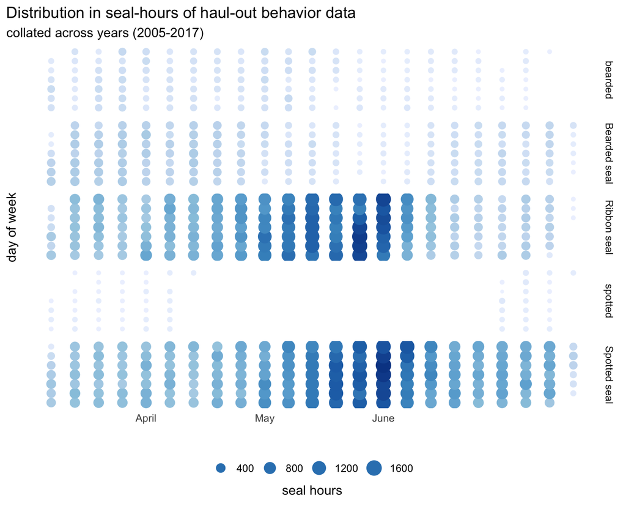

lastly, let’s plot a map of our data so we can get a sense of the geographic distribution for each species

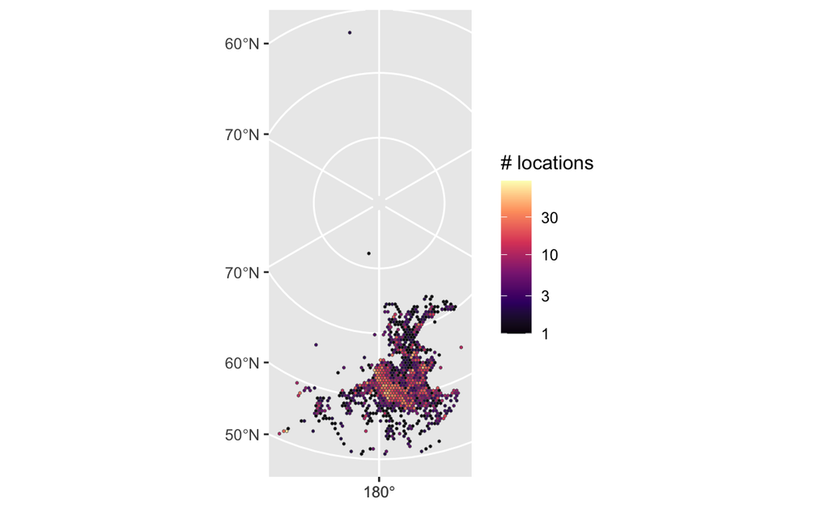

We can see that there are two locations well outside the study area. these are likely a result of very poor quality Argos locations and the averaging used to calculate daily locations for this analysis. We can remove these by filtering based on the speno (*PL2018_1002*) and the two dates (*2018-06-04* and *2018-06-06*).

With the erroneous locations removed, we can plot the distribution of haulout locations for each of our three species

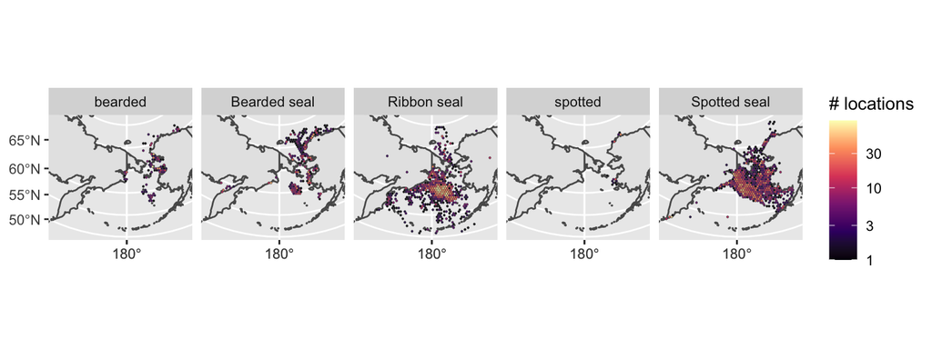